# Calculating Volumes From Timestamps Using R

## Calculating Census Volumes

Calculating census volumes, that is the number of patients waiting in the ED at any given time, requires a different strategy. Among the many strategies of accomplishing this, I will focus on one of the faster algorithms.

The strategy is to imagine having a counter that keeps track of every time a patient enters or leaves the ED. When a patient walks in the door we add one to the overall count, and when a patient leaves we substract one. Since we have the timestamps of when patients enter and leave, this is a very simple task.

We will split our data into two chunks, one for arrivals and one for departures. For each data split we will create a counter variable. This variable will take the value of 1 for the arrival split and -1 for the departure split. We then bind the two splits back together, arrange them by time, and take a cummulative sum of the counter variable.

As with the previous example we need to fill in the gaps where no arrivals or departures exist. Except this time, instead of filling in the gaps with zeros we take the last observation carried forward. Since the data will be arranged by time we can use `tidyr::fill()`.

```r
ed_data <- ed_data %>%
  mutate(arrival_times = floor_date(arrival_times, unit = 'minute'),
         depart_times = floor_date(depart_times, unit = 'minute'))
arrivals <- ed_data %>%
  select(timestamp = arrival_times) %>%
  mutate(counter = 1)

departures <- ed_data %>%
  select(timestamp = depart_times) %>%
  mutate(counter = -1)


census_volumes <- arrivals %>%
  bind_rows(departures) %>%
  arrange(timestamp, counter) %>%  # arrange by time
  mutate(volume = cumsum(counter)) # take cumulative sum of the counter

# create a sequence of times from the start to end of your available data
start <- min(census_volumes$timestamp)
end   <- max(census_volumes$timestamp)
full_time_window <- tibble(timestamp = seq(start, end,
                                           by = 'mins'))
census_volumes <- census_volumes %>%
  right_join(full_time_window,
             by = 'timestamp') %>% # bind with the full time window to fill gaps
  arrange(timestamp) %>%
  fill(volume, .direction = 'down') # take last observation carried forward

census_volumes
```

```
## # A tibble: 3,353 x 3
##    timestamp           counter volume
##    <dttm>                <dbl>  <dbl>
##  1 2018-10-01 00:05:00       1      1
##  2 2018-10-01 00:06:00      NA      1
##  3 2018-10-01 00:07:00      NA      1
##  4 2018-10-01 00:08:00      NA      1
##  5 2018-10-01 00:09:00      NA      1
##  6 2018-10-01 00:10:00      NA      1
##  7 2018-10-01 00:11:00      NA      1
##  8 2018-10-01 00:12:00      NA      1
##  9 2018-10-01 00:13:00      NA      1
## 10 2018-10-01 00:14:00      NA      1
## # ... with 3,343 more rows
```

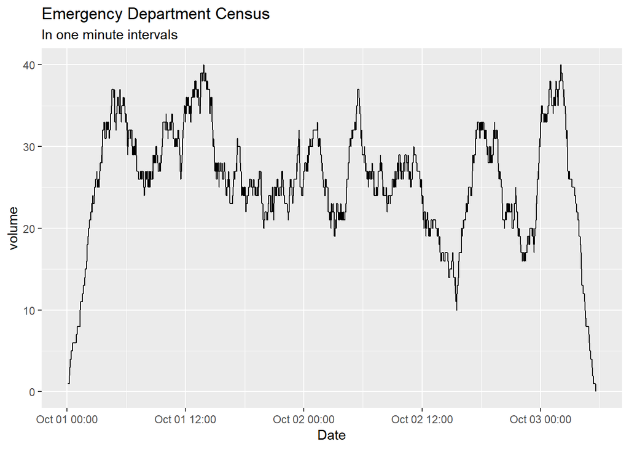

```r
census_volumes %>%
  ggplot(aes(timestamp, volume)) +
  geom_line() +
  xlab('Date') +
  ggtitle('Emergency Department Census',
          subtitle = 'In one minute intervals')
```

It will rarely be the case where you will be calculating these volumes from scratch, i.e. from the opening of the ED. Let’s redo the above example but take October 2nd at midnight as our starting time.

We need to set a start time for our time window. We then calculate the number of people in the ED at the begining of our time window. We preceed as before, but before taking the cumulative sum we set the first row of the data to be the number of people in the ED at the start time.

```r
# set a start time
start_time <- ymd_hms('2018-10-02 00:00:00')


# get the base count
# This is the number of people who arrived to the ED before the start time
# but are still in the ED after the start time
pre <- ed_data %>%
    filter(arrival_times < start_time &
           depart_times >= start_time)

# Anyone who leaves the ED after the start_time
post <- ed_data %>%
  filter(depart_times >= start_time)


# The arrivals
arrivals <- post %>%
  select(timestamp = arrival_times) %>%
  mutate(counter = 1)%>%
  filter(timestamp >= start_time)

# The departures
departures <- post %>%
  select(timestamp = depart_times) %>%
  mutate(counter = -1)


census_volumes <- arrivals %>%
  bind_rows(departures) %>%
  arrange(timestamp, counter)

#  Add the starting pre volume to the first row
census_volumes$counter[1] <- census_volumes$counter[1] + nrow(pre)

census_volumes <- census_volumes %>%  # arrange by time
  mutate(volume = cumsum(counter))

# create a sequence of times from the start to end of your available data
start <- min(census_volumes$timestamp)
end   <- max(census_volumes$timestamp)
full_time_window <- tibble(timestamp = seq(start, end,
                                           by = 'mins'))
census_volumes <- census_volumes %>%
  right_join(full_time_window,
             by = 'timestamp') %>% # bind with the full time window to fill gaps
  arrange(timestamp) %>%
  fill(volume, .direction = 'down') # take last observation carried forward

census_volumes
```

```
## # A tibble: 1,849 x 3
##    timestamp           counter volume
##    <dttm>                <dbl>  <dbl>
##  1 2018-10-02 00:00:00      27     27
##  2 2018-10-02 00:01:00      NA     27
##  3 2018-10-02 00:02:00      NA     27
##  4 2018-10-02 00:03:00      NA     27
##  5 2018-10-02 00:04:00      NA     27
##  6 2018-10-02 00:05:00      NA     27
##  7 2018-10-02 00:06:00      NA     27
##  8 2018-10-02 00:07:00       1     28
##  9 2018-10-02 00:08:00      NA     28
## 10 2018-10-02 00:09:00      NA     28
## # ... with 1,839 more rows
```

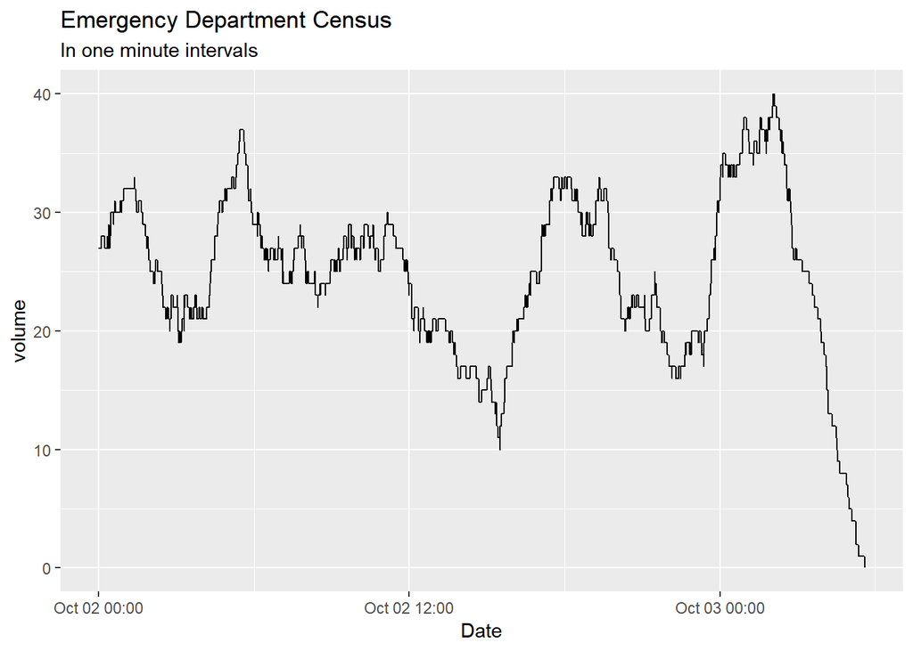

```r
census_volumes %>%
  ggplot(aes(timestamp, volume)) +
  geom_line() +
  xlab('Date') +
  ggtitle('Emergency Department Census',
          subtitle = 'In one minute intervals')
```

## Putting census volume calculation into a function

```r
calc_census_volume <- function(data, start_var, end_var,
                                 begin_time = '2018-10-02 00:00:00') {
  sv <- rlang::enquo(start_var)
  ev <- rlang::enquo(end_var)

   if(!inherits(begin_time, 'POSIXct')) {
    begin_time <- lubridate::ymd_hms(begin_time)
  }


  # keep track of timestamp issues
  incorrect_times <- data %>%
    dplyr::filter(!!ev < !!sv | is.na(!!ev) | is.na(!!sv)) %>%
    dplyr::mutate(type = ifelse( is.na(!!ev) ,
                                 'missing end timestamp',
                          ifelse(is.na(!!sv),
                                 'missing start timestamp',
                                 'end timestamp before start timestamp')))
  # remove timestamp problems
  filtered_data <- data %>%
    dplyr::filter(!!sv <= !!ev) %>%   # no end timestamps after start timestapms
    dplyr::filter(!is.na(!!ev)) %>%  # no missing end times
    dplyr::filter(!is.na(!!sv))  # no missing start times


  # get the base count
  pre <- filtered_data %>%
    dplyr::filter(!!sv < begin_time &
             !!ev >= begin_time)

   post <- filtered_data %>%
    dplyr::filter(!!ev >= begin_time)

  # The arrivals
  arrivals <- post %>%
    dplyr::select(timestamp = !!sv) %>%
    dplyr::mutate(counter = 1) %>%
    dplyr::filter(timestamp >= start_time)

  # The departures
  departures <- post %>%
    dplyr::select(timestamp = !!ev) %>%
    dplyr::mutate(counter = -1)

  # bind the arrivals and departures
  census_volumes <- arrivals %>%
    dplyr::bind_rows(departures) %>%
    dplyr::arrange(timestamp, counter)

  # Add the starting pre volume to the first row
  census_volumes$counter[1] <- census_volumes$counter[1] + nrow(pre)

  census_volumes <- census_volumes %>%  # arrange by time
    dplyr::mutate(volume = cumsum(counter))

  # create a sequence of times from the start to end of your available data
  start <- min(census_volumes$timestamp)
  end   <- max(census_volumes$timestamp)
  full_time_window <- dplyr::tibble(timestamp = seq(start, end,
                                           by = 'mins'))
  census_volumes <- census_volumes %>%
    right_join(full_time_window,
               by = 'timestamp') %>% # bind with the full time window to fill gaps
    arrange(timestamp) %>%
    fill(volume, .direction = 'down') # take last observation carried forward

  if(nrow(incorrect_times) > 0) {
    incorrect_times_sum <- incorrect_times %>%
      dplyr::count(type)

    msg <- paste0(paste(incorrect_times_sum$type,
                        incorrect_times_sum$n, sep = ': n = '),
                  collapse = '\n')
    msg <- paste0('Potential Data Issues:\n',
                  msg,
                  '\nThese timestamp errors have been removed from the
                  data prior to volume calculation')
    message(msg)
  }

  return(census_volumes)

}

# try the function

ed_data %>%
  calc_census_volume(start_var = arrival_times,
                     end_var = depart_times)
```

```
## # A tibble: 1,849 x 3
##    timestamp           counter volume
##    <dttm>                <dbl>  <dbl>
##  1 2018-10-02 00:00:00      27     27
##  2 2018-10-02 00:01:00      NA     27
##  3 2018-10-02 00:02:00      NA     27
##  4 2018-10-02 00:03:00      NA     27
##  5 2018-10-02 00:04:00      NA     27
##  6 2018-10-02 00:05:00      NA     27
##  7 2018-10-02 00:06:00      NA     27
##  8 2018-10-02 00:07:00       1     28
##  9 2018-10-02 00:08:00      NA     28
## 10 2018-10-02 00:09:00      NA     28
## # ... with 1,839 more rows
```

## Conclusion

The two strategies discussed here can be used for most volume calculations. Before proceeding with either algorithm it is good practice to have a look at your timestamps for accuracy. In using raw timestamp from an Electronic Medical Records system, we may run into some data inconsistencies. It is always a good idea to run some data quality checks before using such data. For example, make sure that there are no departure timestamps that occur before the arrival timestamps.